# Analysis of Unknown Transcripts

Joshua Medina

7/21/2020

#### Loading database and setting the directory.

```r
suppressMessages(library(DESeq2))
suppressMessages(library(gplots))
suppressMessages(library(RColorBrewer))
suppressMessages(library(EnhancedVolcano))
suppressMessages(library(tidyverse))
suppressMessages(library(gridExtra))
suppressMessages(library(grid))
suppressMessages(library(ggplot2))
suppressMessages(library(scales))
suppressMessages(library(ggpubr))
```

#### Loading the data

```r
ddata <- read.table("data/pdata.txt", header = TRUE)
```

Generating the data set with respect to the counts. Here the count files generated with salmon are going to be used for the DGE quantification. Note: We have to change the ID of our transcripts of interests in order to visualize them better further in our analysis.

- Transcript_411139 = TRINITY_DN1758_c0_g1_i6 = FReD1
- Transcript_456418 = TRINITY_DN35952_c0_g1_i1 = FReD2
- Transcript_201140 = TRINITY_DN59828_c0_g4_i1 = FReD3
- Transcript_369809 = TRINITY_DN23328_c0_g1_i1 = FReD4
- Transcript_299020 = TRINITY_DN428_c2_g1_i1 = FReD5
- Transcript_330815 = TRINITY_DN11691_c0_g1_i5 = FN31
- Transcript_202375 = TRINITY_DN1286_c0_g1_i2 = EGF1
- Transcript_339471 = TRINITY_DN6966_c0_g1_i4 = EGF2
- Transcript_339473 = TRINITY_DN6966_c0_g1_i7 = EGF3
- Transcript_257591 = TRINITY_DN83143_c0_g1_i2 = EGF4
- Transcript_298293 = TRINITY_DN485_c0_g1_i1 = FN32

```r
ddsSTAR <- DESeqDataSetFromHTSeqCount(sampleTable = ddata, directory = "counts_global", design = ~ condition)

colData(ddsSTAR)$condition <- factor(colData(ddsSTAR)$condition, levels = levels(ddata$condition))


ddsSTAR@rowRanges@partitioning@NAMES[ddsSTAR@rowRanges@partitioning@NAMES == 'TRINITY_DN1758_c0_g1_i6'] <- 'T_FReD1'
ddsSTAR@rowRanges@partitioning@NAMES[ddsSTAR@rowRanges@partitioning@NAMES == 'TRINITY_DN35952_c0_g1_i1'] <- 'T_FReD2'
ddsSTAR@rowRanges@partitioning@NAMES[ddsSTAR@rowRanges@partitioning@NAMES == 'TRINITY_DN59828_c0_g4_i1'] <- 'T_FReD3'
ddsSTAR@rowRanges@partitioning@NAMES[ddsSTAR@rowRanges@partitioning@NAMES == 'TRINITY_DN23328_c0_g1_i1'] <- 'T_FReD4'
ddsSTAR@rowRanges@partitioning@NAMES[ddsSTAR@rowRanges@partitioning@NAMES == 'TRINITY_DN428_c2_g1_i1'] <- 'T_FReD5'
ddsSTAR@rowRanges@partitioning@NAMES[ddsSTAR@rowRanges@partitioning@NAMES == 'TRINITY_DN11691_c0_g1_i5'] <- 'T_FN31'
ddsSTAR@rowRanges@partitioning@NAMES[ddsSTAR@rowRanges@partitioning@NAMES == 'TRINITY_DN1286_c0_g1_i2'] <- 'T_EGF1'
ddsSTAR@rowRanges@partitioning@NAMES[ddsSTAR@rowRanges@partitioning@NAMES == 'TRINITY_DN6966_c0_g1_i4'] <- 'T_EGF2'
ddsSTAR@rowRanges@partitioning@NAMES[ddsSTAR@rowRanges@partitioning@NAMES == 'TRINITY_DN6966_c0_g1_i7'] <- 'T_EGF3'
ddsSTAR@rowRanges@partitioning@NAMES[ddsSTAR@rowRanges@partitioning@NAMES == 'TRINITY_DN83143_c0_g1_i2'] <- 'T_EGF4'
ddsSTAR@rowRanges@partitioning@NAMES[ddsSTAR@rowRanges@partitioning@NAMES == 'TRINITY_DN485_c0_g1_i1'] <- 'T_FN32'
```

Estimating the size factors using *“median ratio method”*, dispersions (gene-wise, mean-dispersion relationship, final dispersion estimates). Generating the counts table with *counts* function.

```r
dds <- estimateSizeFactors(ddsSTAR)
dds <- estimateDispersions(dds)
dds <- nbinomWaldTest(dds)
counts_table <- counts(dds, normalized=TRUE)
```

Results of contrasts between conditions (1DPE vs NORMAL; 3DPE vs NORMAL). **Note: Normal tissue is referred as non regenerated mesentery tissue of the sea cucumber.**

```r
res_1DPE <- results(dds, contrast = c("condition", "1DPE", "Control"))
res_1DPE <- res_1DPE[order(res_1DPE$padj),]

res_3DPE <- results(dds, contrast = c("condition", "3DPE", "Control"))
res_3DPE <- res_3DPE[order(res_3DPE$padj),]
```

#### Visualization of the results.

Plotting dispersion estimates.

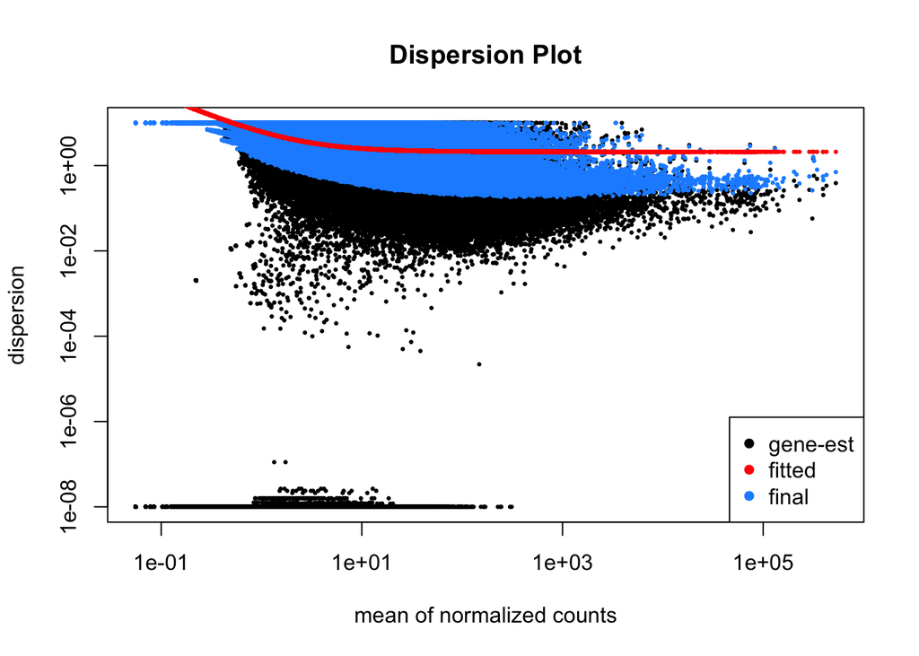

```r
DESeq2::plotDispEsts(dds,main="Dispersion Plot")
```

#### Raw Data vs Normalized Data Counts.

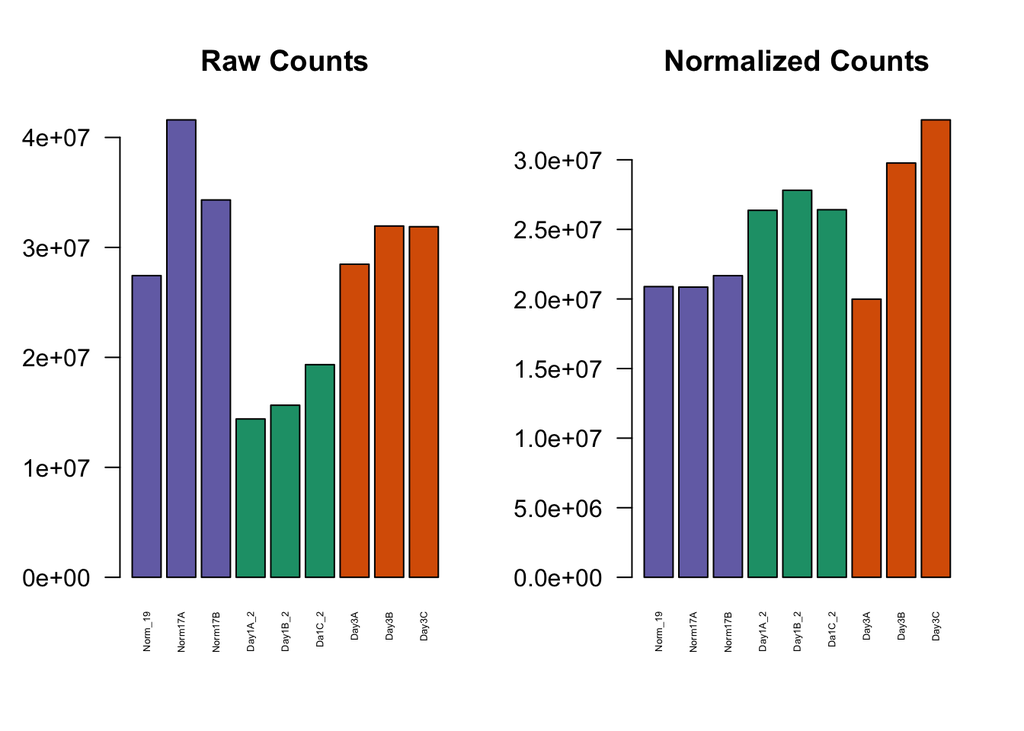

```r
conds <- as.vector(ddata$condition)
condcols <- brewer.pal(n = length(unique(conds)), name="Dark2")
par(mfrow=c(1,2))
barplot(colSums(counts(dds, normalized=F)), col = condcols[as.factor(conds)], las = 2, cex.names=0.4, main="Raw Counts")
barplot(colSums(counts(dds, normalized=T)), col=condcols[as.factor(conds)], las=2, cex.names = 0.4, main = "Normalized Counts")
```

#### PCA Plot – to see the relationship between datasets.

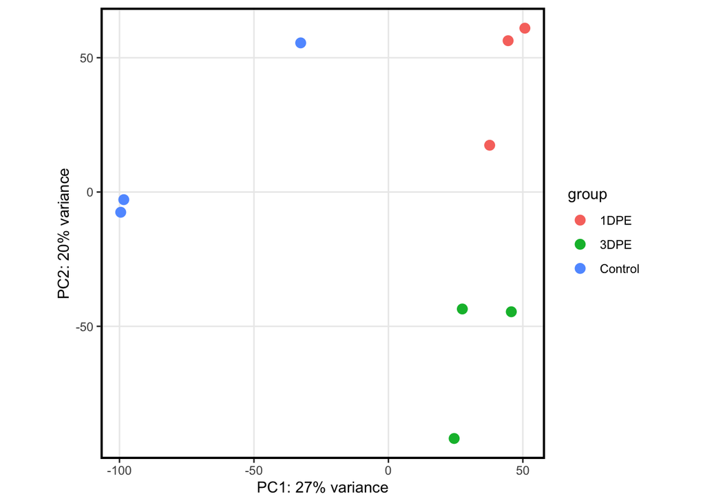

```r
vsd <- varianceStabilizingTransformation(dds)
PCA <- DESeq2::plotPCA(vsd)+theme_bw()+
  theme(panel.grid.minor = element_blank(), panel.border = element_rect(fill=NA, colour = "black", size=1.5))

PCA
```

#### Processing Data

Even though we already saved the data we are going to do some further data wrangling in order to obtain the information we want in the way we need it.

```r
res1dpe <- as.data.frame(res_1DPE)
res1dpe$names <- rownames(res1dpe)
rownames(res1dpe) <- NULL

res3dpe <- as.data.frame(res_3DPE)
res3dpe$names <- rownames(res3dpe)
rownames(res3dpe) <- NULL


transcripts.1dpe <- res1dpe %>% filter(grepl('T_', names)) %>% add_column(condition = '1dpe')
transcripts.3dpe <- res3dpe %>% filter(grepl('T_', names)) %>% add_column(condition = '3dpe')

transcripts <- rbind(transcripts.1dpe, transcripts.3dpe)
transcripts$color <- ifelse(transcripts$padj < 0.05, 'yes', 'no')
transcripts$color2 <- ifelse(transcripts$pvalue < 0.05, 'yes', 'no')
```

#### Generating the plots to visualize the expression and significance of our transcripts.

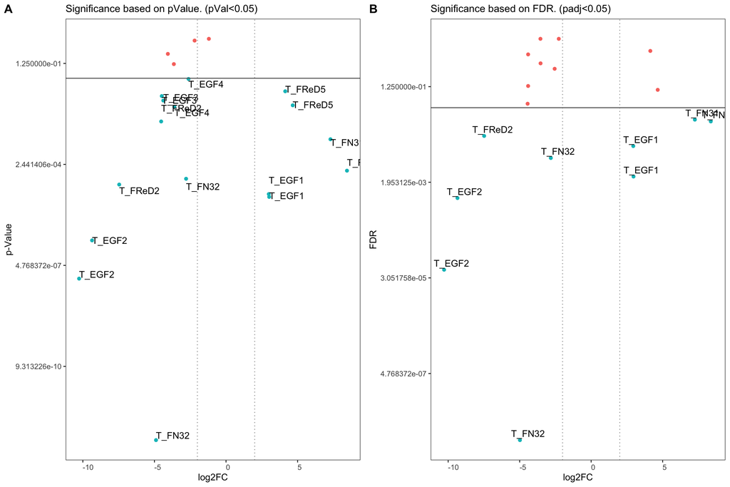

```r
plot1 <- ggplot(transcripts) + ggtitle("Significance based on FDR. (padj<0.05)") +
  geom_point(aes(x = log2FoldChange, y = padj, color = color), position = position_jitter(w = 0.1, h = 0)) +
  xlab("log2FC") + ylab("FDR") + theme_bw() +
  theme(axis.text.x = element_text(angle = 0, hjust = 0), plot.title = element_text(size = 12),
        legend.position = "none", panel.grid.major = element_blank(), panel.grid.minor = element_blank()) +
  scale_y_continuous(trans='log2') + geom_hline(yintercept = 0.05, colour = "grey40") + geom_vline(xintercept = c(-2,2), colour = "grey40", size = 0.3, linetype = 3) +
  geom_text(data = subset(transcripts, padj < 0.05), aes(log2FoldChange, padj, label = names), hjust=0.3,vjust=-0.5)

plot1.b <- ggplot(transcripts) + ggtitle("Significance based on pValue. (pVal<0.05)") +
  geom_point(aes(x = log2FoldChange, y = pvalue, color = color2)) +
  xlab("log2FC") + ylab("p-Value") + theme_bw() +
    theme(axis.text.x = element_text(angle = 0, hjust = 0), plot.title = element_text(size = 12),
          legend.position = "none", panel.grid.major = element_blank(), panel.grid.minor = element_blank()) +
  scale_y_continuous(trans='log2') + geom_hline(yintercept = 0.05, colour = "grey40") + geom_vline(xintercept = c(-2,2), colour = "grey40", size = 0.3, linetype = 3) +
  geom_text(data = subset(transcripts, pvalue < 0.05), aes(log2FoldChange, pvalue, label = names), hjust=0,vjust=0, position=position_jitter(width=-1,height=1))

ggarrange(plot1.b, plot1,
          labels = c("A", "B"),
          ncol = 2)
```

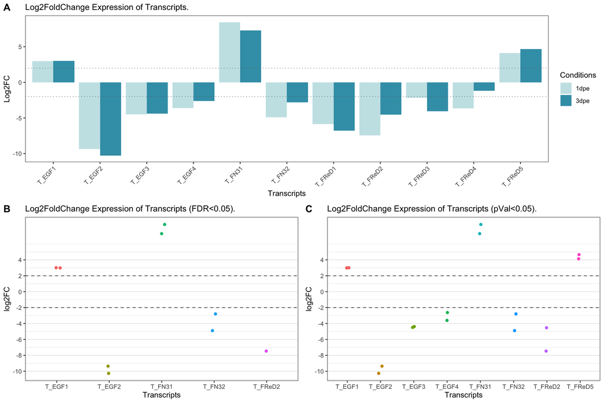

```r
plot2 <- ggplot(transcripts) + ggtitle("Log2FoldChange Expression of Transcripts.") +
  geom_bar (aes(x = names, y = log2FoldChange, fill = condition), stat = "identity", position=position_dodge()) +
  xlab("Transcripts") + ylab("Log2FC") + theme_bw() +
  theme(axis.text.x = element_text(angle = 45, hjust = 1), plot.title = element_text(size = 12),
        panel.grid.major = element_blank(), panel.grid.minor = element_blank()) +
  scale_fill_manual(name = "Conditions", values = c("#C8E4E7", "#3D9EB5")) +
  geom_hline(yintercept = c(-2,2), colour = "grey40", size = 0.3, linetype = 3)

plot3 <- ggplot(data = subset(transcripts, color == 'yes')) + ggtitle("Log2FoldChange Expression of Transcripts (FDR<0.05).") +
  geom_point(aes(x = names, y = log2FoldChange, color = names), stat = "identity", position = position_jitter(w = 0.07, h = 0)) +
  xlab("Transcripts") + ylab("log2FC") + theme_bw() +
  theme(axis.text.x = element_text(angle = 0), legend.position = "none", plot.title = element_text(size = 12),
        panel.grid.major.x = element_blank(), panel.grid.minor.x = element_blank()) +
  geom_hline(yintercept = c(2, -2), colour = "grey40", linetype = 2) +
  scale_y_continuous(breaks=seq(-10,4,2))


plot3.b <- ggplot(data = subset(transcripts, color2 == 'yes')) + ggtitle("Log2FoldChange Expression of Transcripts (pVal<0.05).") +
  geom_point(aes(x = names, y = log2FoldChange, color = names), stat = "identity", position = position_jitter(w = 0.07, h = 0)) +
  xlab("Transcripts") + ylab("log2FC") + theme_bw() +
  theme(axis.text.x = element_text(angle = 0), legend.position = "none", plot.title = element_text(size = 12),
        panel.grid.major.x = element_blank(), panel.grid.minor.x = element_blank()) +
  geom_hline(yintercept = c(2, -2), colour = "grey40", linetype = 2) +
  scale_y_continuous(breaks=seq(-10,4,2))


ggarrange(plot2,                                                 # First row with barplot
          ggarrange(plot3, plot3.b, ncol = 2, labels = c("B", "C")), # Second row with scatter plots
          nrow = 2,
          labels = "A"                                        # Labels of the barplot
          )
```

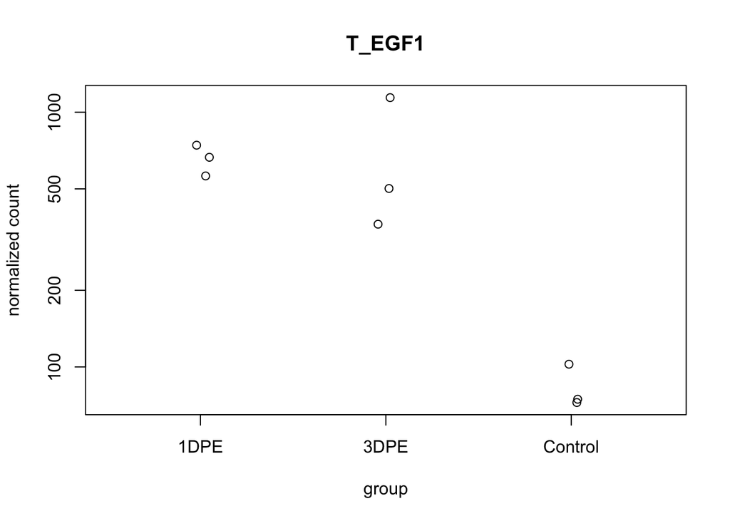

```r
plotCounts(dds, gene="T_EGF1", intgroup="condition")
```